# Probability

## Uncertainty & Science

> Scientific knowledge is a body of statements of varying degrees of certainty—some most unsure, some nearly sure, none absolutely certain (Feynman)

Probability is a way to quantify uncertainty.

## Why learn probability?

Basis of logical deduction

- Should you fly or drive?
- Should you not eat raw cookie dough?

Basis of inference systems

- Likelihood and Bayesian

Basis of P-values

- Cornerstone of null hypothesis testing

## Basics of probability

The probability of an event is the proportion of times the event would occur if a random trial is repeated infinitely under constant conditions.

## Basics of probability

The probability of an event is the **proportion** of times the event **would** occur **if** a **random** trial is repeated **infinitely** under **constant conditions**.

- proportion
- would occur
- if
- random trial
- infinitely
- constant conditions

## Basics of probability

The probability of an event is the **proportion** of times the event **would** occur **if** a **random** trial is repeated **infinitely** under **constant conditions**.

[figure not shown]

## Basics of probability

Probabilities are proportions.

Pr[event] is the abbreviation for “the probability of event A occurring.”

- \(Pr[heads] = 0.50\): Heads
- \(Pr[heads'] = 0.50\): *Not* heads

The range of probabilities for an event is 0 \(\rightarrow\) 1 (including 0 and 1).

## Addition rule

### Mutually exclusive events

*Mutually exclusive* events are events that are not simultaneously possible due to constraints of physics, biology, development, evolution, etc.

- \(Pr[A~and~B] = Pr[A, B] = 0\)
- Probability of A and B occurring simultaneously.
- e.g., You can’t flip a coin heads and tails in one trial
  - \(Pr[H, T] = 0\)
- \(Pr[A~or~B] = Pr[A] + Pr[B]\)

## Addition rule

### Mutually exclusive events

On a single die roll, what is the probability of rolling *either* a 1 *or* a 2?

On a single die roll, what is the probability of rolling *either* a 1, a 2, *or* a 3?

## Multiplication rule

### Independent events

If events are *independent*, then their individual probabilities do not influence each other.

- The occurrence of one does not alter the probability of the other.
- Successive coin flips
- Successive die rolls
- Successive roulette wheel spins
- Weekly lottery drawings
- Offspring sex

## Multiplication rule

### Independent events

\[Pr[A, B] = Pr[A] \times Pr[B]\] In two successive die rolls, what is the probability of rolling a 1 *followed by* a 2?

In three successive die rolls, what is the probability of rolling a 1 *followed by* a 2, *followed by* a 6?

## Multiplication rule

### Independent events

\[Pr[A, B] = Pr[A] \times Pr[B]\]

[figure not shown]

## Binomial probabilities

KM’s sister has 4 children of which 4 are girls.

What is the probability of having 4 children that are all girls if \(Pr[girl]=0.488\)?

[figure not shown]

## Binomial probabilities

```r
0.488 ^ 4
```

```
## [1] 0.05671256
```

```r
dbinom(4, 4, 0.488)
```

```
## [1] 0.05671256
```

Imagine KM’s sister really wants a boy. What is the probability her next child will be a boy?

## Binomial Distribution

- Probability distributions are basically like counting the ways things can happen
- In R, you can “flip a coin” using the binomial distribution. The function is `rbinom()`. Try one flip: `rbinom(1, 1, 0.5)`

## Binomial Distribution

If we flip a coin once, possible outcomes are H or T. How many ways are there to get one H? One T?

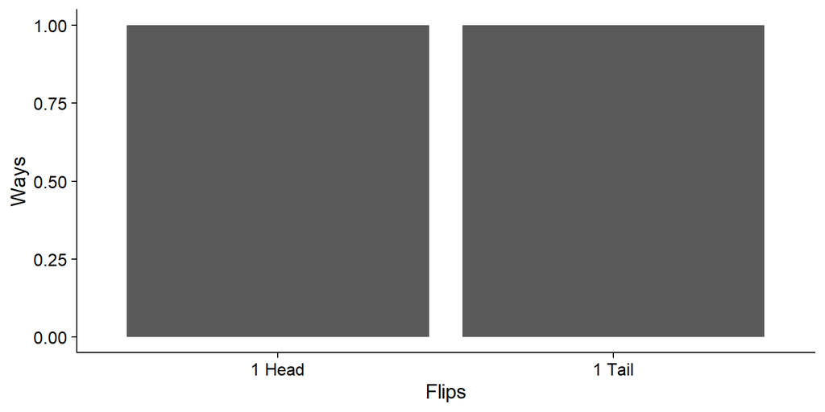

## Binomial Distribution

If we flip a coin twice, what are the possible outcomes?

1. HH
2. HT, TH
3. TT

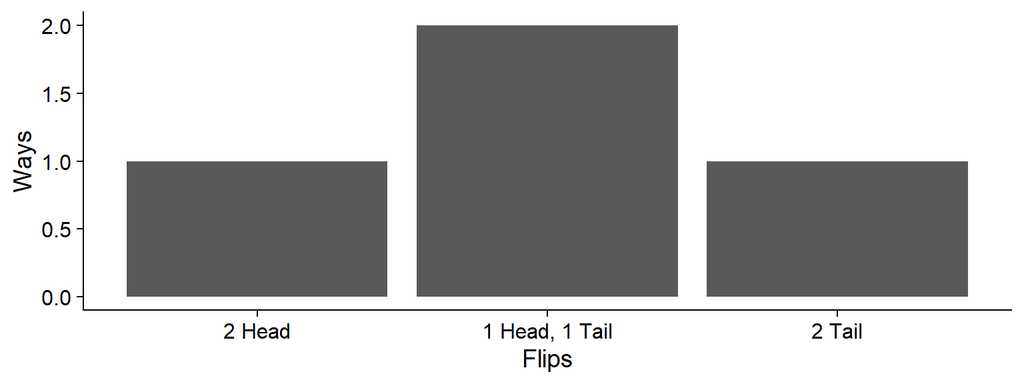

## Binomial Distribution

If we flip a coin 3 times, what are the possible outcomes?

1. HHH
2. HHT, HTH, THH
3. TTH, THT, HTT
4. TTT

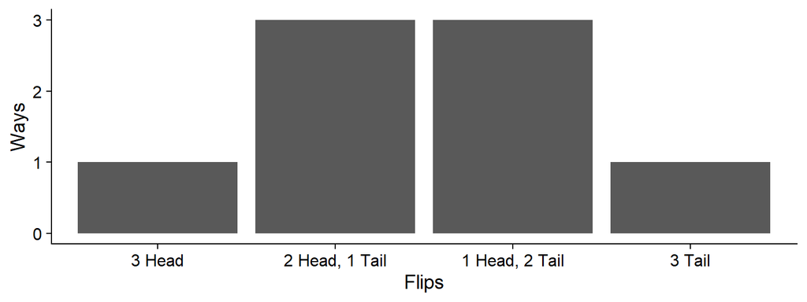

## Binomial Distribution

If we flip a coin 4 times, what are the possible outcomes?

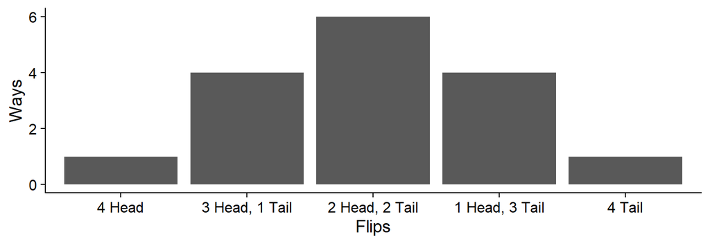

## Binomial Distribution

If we flip a coin 6 times, what are the possible outcomes?

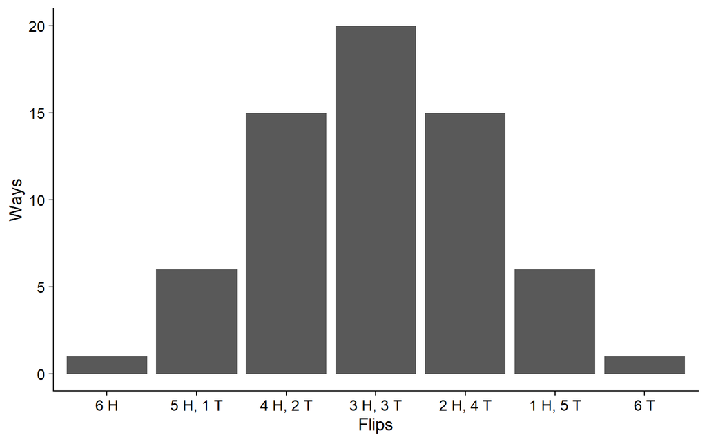